# Empirical and Null-Model Metrics Comparison

Xinrui Shi

2026-08-04

# Network-type comparison

Network types in the empirical database and null model

| Data | type | Networks |
| --- | --- | --- |
| Null Model | Looped | 293 |
| Null Model | Star | 1 |
| Null Model | Non-star tree | 6 |
| Database | Looped | 241 |
| Database | Star | 37 |
| Database | Non-star tree | 22 |

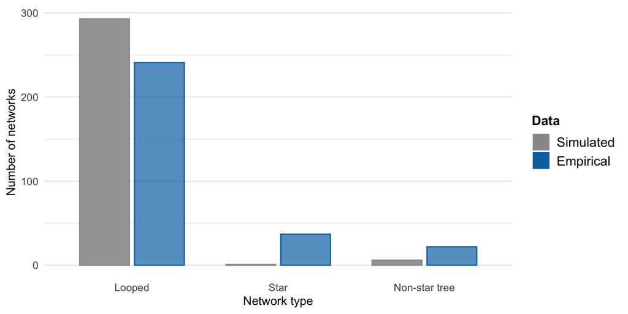

# Degree-distribution comparison

The layout follows the all-degree-distribution figure in `soft_config_model.Rmd`. Panel (b) shows separate maximum-likelihood shifted-geometric fits for the empirical database and null model. Panels (a) and (c) contain no fitted lines.

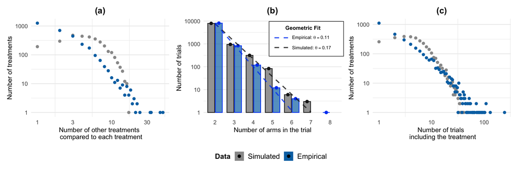

```
## Null model: Number of treatments have fewer than 3 degrees: 489
```

```
## Null model: Proportion of treatments have fewer than 3 degrees: 0.1560804
```

```
## Empirical: Number of treatments have fewer than 3 degrees: 1957
```

```
## Empirical: Proportion of treatments have fewer than 3 degrees: 0.6264405
```

```
## Null model: Number of treatments have more than 3 degrees: 2166
```

```
## Null model: Proportion of treatments have more than 3 degrees: 0.6913501
```

```
## Empirical: Number of treatments have more than 3 degrees: 721
```

```
## Empirical: Proportion of treatments have more than 3 degrees: 0.2307939
```

[output not shown]

```
## Empirical: maximum treatment degree = 245
```

```
## Simulation: maximum treatment degree = 41
```

```
## Empirical: proportion of 2-arm trials =  0.8932286
```

```
## Simulation: proportion of 2-arm trials =  0.8531514
```

# Edge multiplicity

The multiplicity of an edge is the number of trials in which the same pair of treatments is compared. Each unordered pair is counted once per network. Panel (b) shows the distribution of the total number of edges per network; each dataset contributes one value for each of its 300 networks.

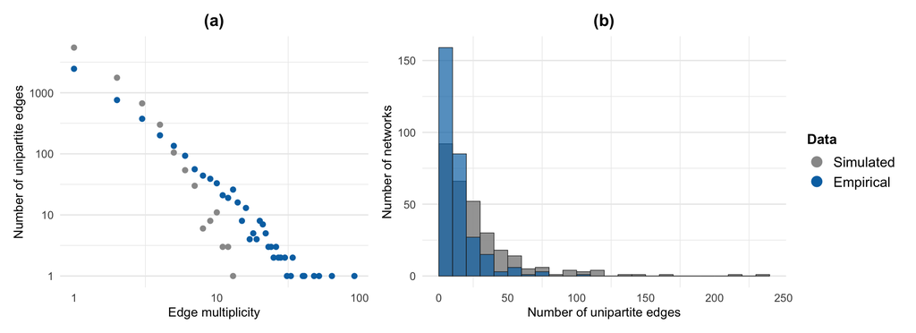

## Number of distinct treatment pairs

This standalone version of panel (b) shows the exact number of networks at each observed number of distinct treatment pairs. It is displayed in the report but is not saved as a separate file.

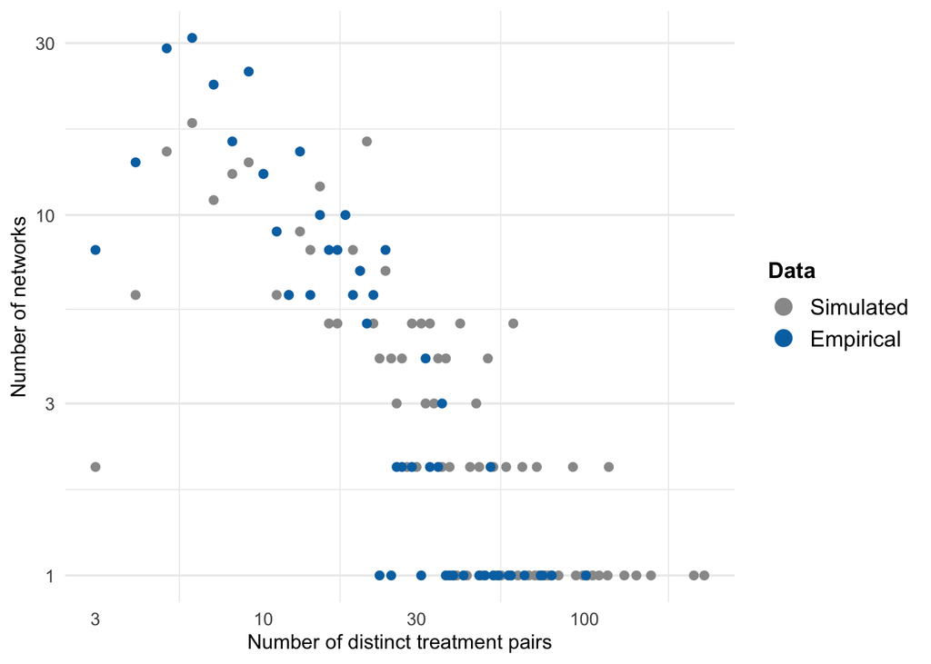

```
## Total number of treatment-pair edge in empirical data: 4366
```

```
## maximal multiplicity in empirical data: 92
```

```
## proportion of multiplicity<5 in empirical data: 0.871049
```

```
## Total number of treatment-pair edge in simulated data: 8445
```

```
## maximal multiplicity in simulated data: 13
```

```
## proportion of multiplicity<5 in simulated data: 0.9738307
```

```
## Number of empirical networks having distinct pairs <=10: 159
```

```
## Number of empirical networks having distinct pairs 10< x <=20: 85
```

```
## empirical networks: maximum distinct pairs: 101
```

```
## Number of null model  networks having distinct pairs <=10: 92
```

```
## Number of null model  networks having distinct pairs 10< x <=20: 66
```

```
## null model networks: maximum distinct pairs: 236
```

# Density

## Unipartite

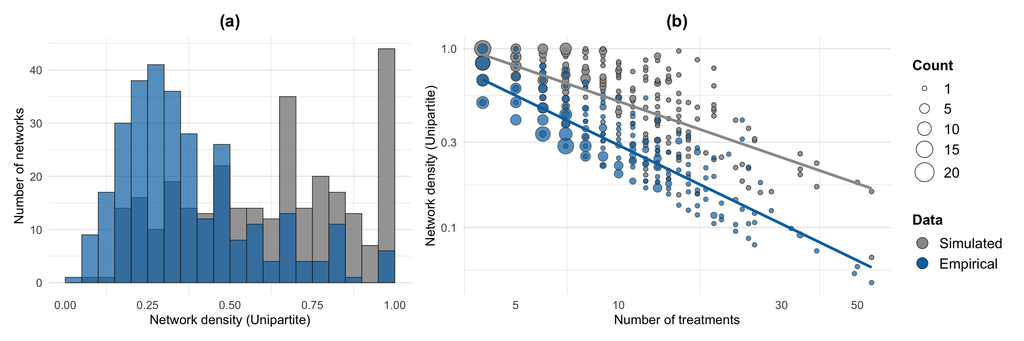

| Data | Networks | Minimum | Mean | Maximum |
| --- | --- | --- | --- | --- |
| Null Model | 300 | 0.068 | 0.615 | 1 |
| Database | 300 | 0.049 | 0.377 | 1 |

```
## Proporton of empirical networks having density>0.5: 0.2066667
```

```
## Number of empirical networks having density 1: 6
```

```
## Number of simulated networks having density 1: 34
```

```
## Doubling the number of treatments is associated with an approximately 47% reduction in unipartite density.
```

## Bipartite

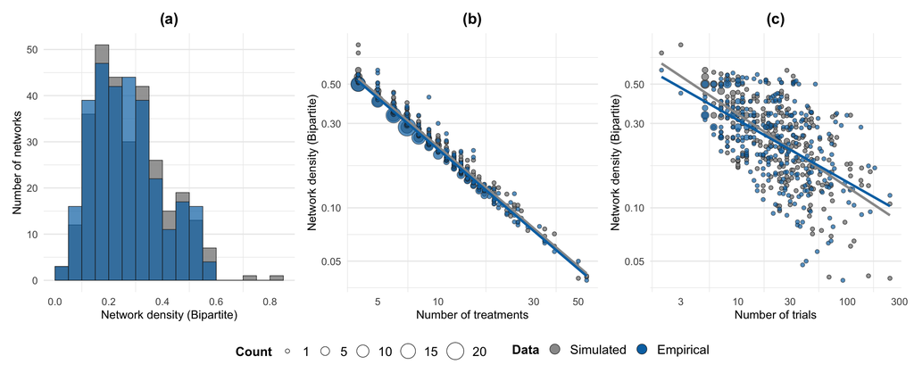

| Data | Networks | Minimum | Mean | Maximum |
| --- | --- | --- | --- | --- |
| Null Model | 300 | 0.040 | 0.284 | 0.833 |
| Database | 300 | 0.039 | 0.273 | 0.600 |

```
## Doubling the number of treatments is associated with an approximately 49% reduction in bipartite density.
```

```
## Doubling the number of trials is associated with an approximately 22% reduction in bipartite density.
```

# Average path length

## Unipartite

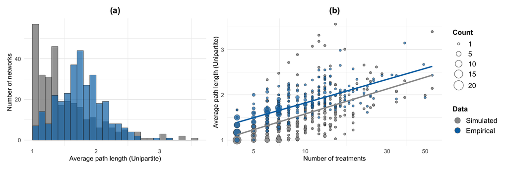

| Data | Networks | Minimum | Mean | Maximum |
| --- | --- | --- | --- | --- |
| Null Model | 300 | 1 | 1.517 | 3.562 |
| Database | 300 | 1 | 1.765 | 3.145 |

```
## Doubling the number of treatments is associated with an approximately 0.33 increase in unipartite APL.
```

## Unipartite diameter

Diameter is the maximum shortest-path distance between any two treatments in the connected unipartite network.

```
##     network_id N_treatments N_total_trials number_of_arms
## 226    570-246           38             53            114
##     number_of_distinct_treatment_comparisons mean_bipartite_trial_degree
## 226                                       52                    2.150943
##     mean_bipartite_treatment_degree mean_unipartite_weighted_degree
## 226                               3                        3.736842
##     mean_unipartite_unweighted_degree    density bi_density avg_path_length
## 226                          2.736842 0.07396871 0.05660377        3.145092
##     diameter   bi_apl unipartite_c bipartite_c assortativity bi_assortativity
## 226        8 5.176557    0.2207792  0.09756098     -0.256743      -0.01826805
##     deg_irreg bi_trial_deg_irreg bi_treatment_deg_irreg   type
## 226  1.491371         0.04401354               1.467836 looped
```

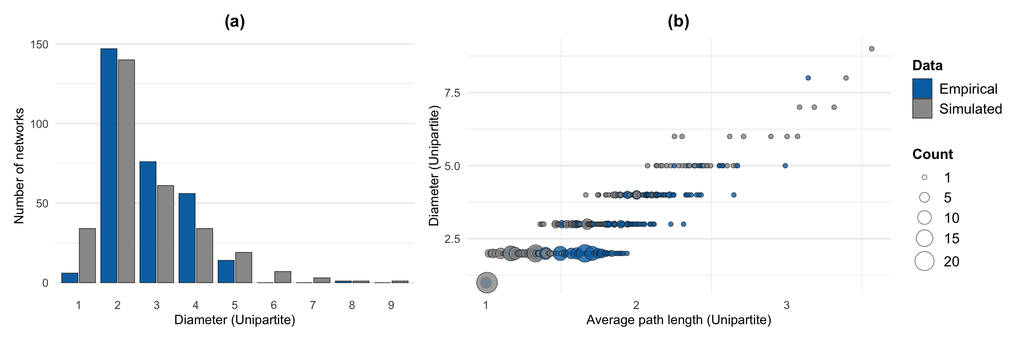

| Data | Networks | Minimum | Mean | Maximum |
| --- | --- | --- | --- | --- |
| Null Model | 300 | 1 | 2.693 | 9 |
| Database | 300 | 1 | 2.767 | 8 |

## Bipartite

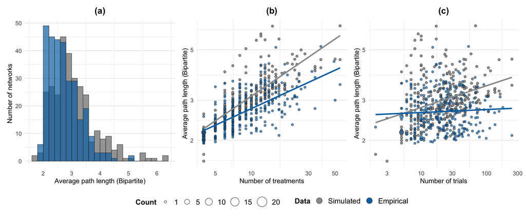

| Data | Networks | Minimum | Mean | Maximum |
| --- | --- | --- | --- | --- |
| Null Model | 300 | 1.619 | 3.081 | 6.379 |
| Database | 300 | 1.939 | 2.729 | 5.177 |

# Clustering coefficient

## Unipartite

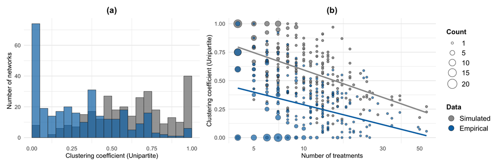

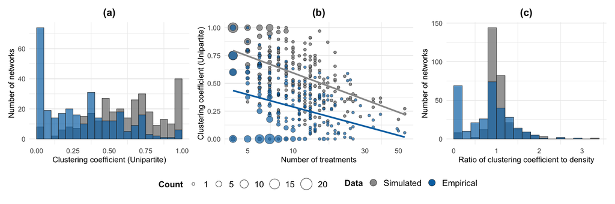

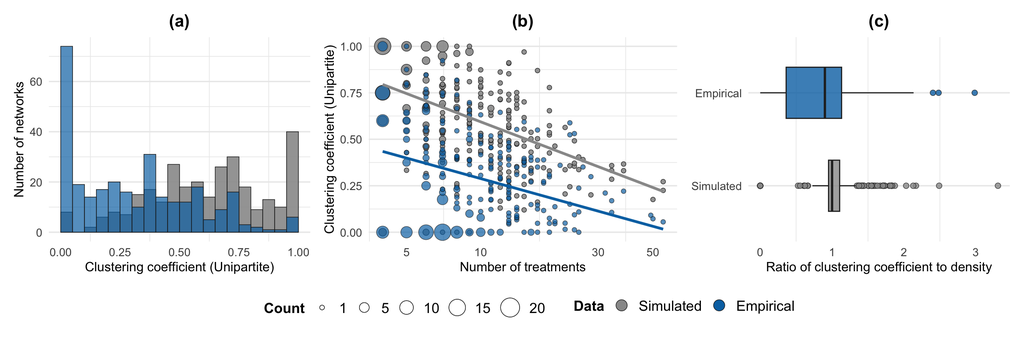

| Data | Networks | Minimum | Mean | Maximum |
| --- | --- | --- | --- | --- |
| Null Model | 300 | 0 | 0.621 | 1 |
| Database | 300 | 0 | 0.308 | 1 |

```
## # A tibble: 3 × 2
## # Groups:   type [3]
##   type       n
##   <chr>  <int>
## 1 looped     8
## 2 star      37
## 3 tree      22
```

```
## Number of networks with C=1 in empirical set: 6
```

```
## Number of networks with C=1 in simulation set: 34
```

```
## Number of networks with C>0.5 in empirical set: 0.2433333
```

```
## Number of networks with C=0.5 in simulation set: 0.66
```

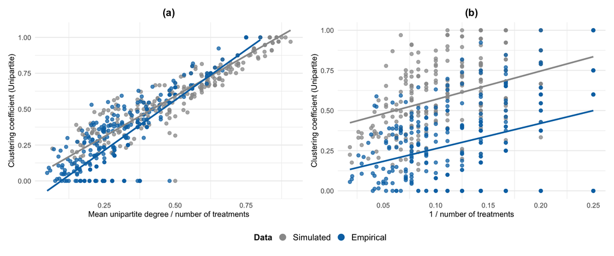

Linear regressions of unipartite clustering coefficient

| Relationship | Data | Intercept | Slope | R-squared |
| --- | --- | --- | --- | --- |
| (a) Mean unipartite degree / N | Simulated | 0.0277 | 1.1273 | 0.8384 |
| (a) Mean unipartite degree / N | Empirical | -0.1369 | 1.4001 | 0.6754 |
| (b) 1 / N | Simulated | 0.3915 | 1.7748 | 0.1958 |
| (b) 1 / N | Empirical | 0.1046 | 1.5807 | 0.1339 |

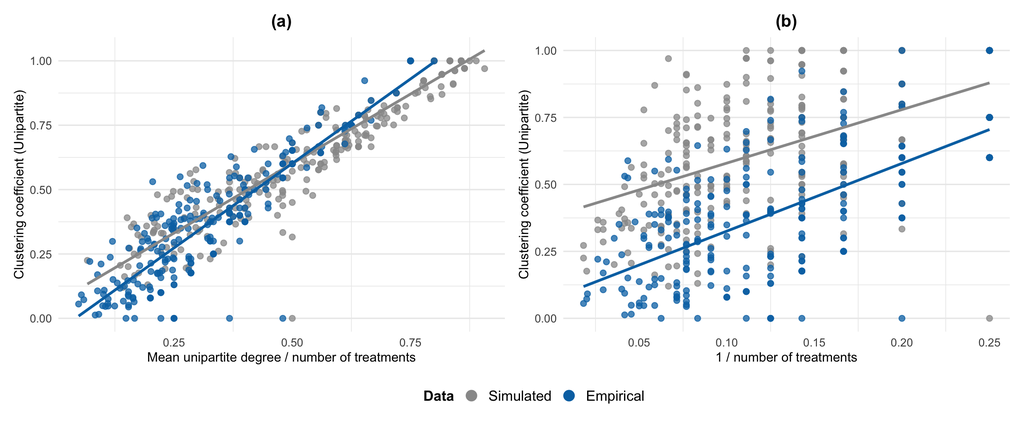

Linear regressions for looped networks only

| Relationship | Data | Intercept | Slope | R-squared |
| --- | --- | --- | --- | --- |
| (a) Mean unipartite degree / N | Simulated | 0.0612 | 1.0799 | 0.8673 |
| (a) Mean unipartite degree / N | Empirical | -0.0546 | 1.3124 | 0.8074 |
| (b) 1 / N | Simulated | 0.3798 | 1.9973 | 0.2821 |
| (b) 1 / N | Empirical | 0.0728 | 2.5285 | 0.4151 |

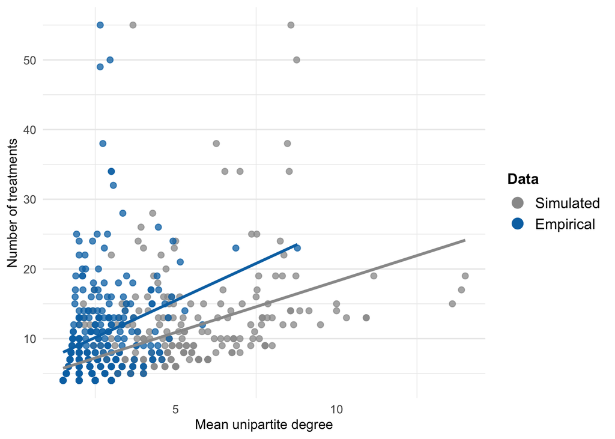

Linear regression of the number of treatments on mean unipartite degree for all networks

| Data | Intercept | Slope | R-squared |
| --- | --- | --- | --- |
| Simulated | 3.5490 | 1.4699 | 0.2012 |
| Empirical | 4.8533 | 2.1256 | 0.0784 |

## Bipartite

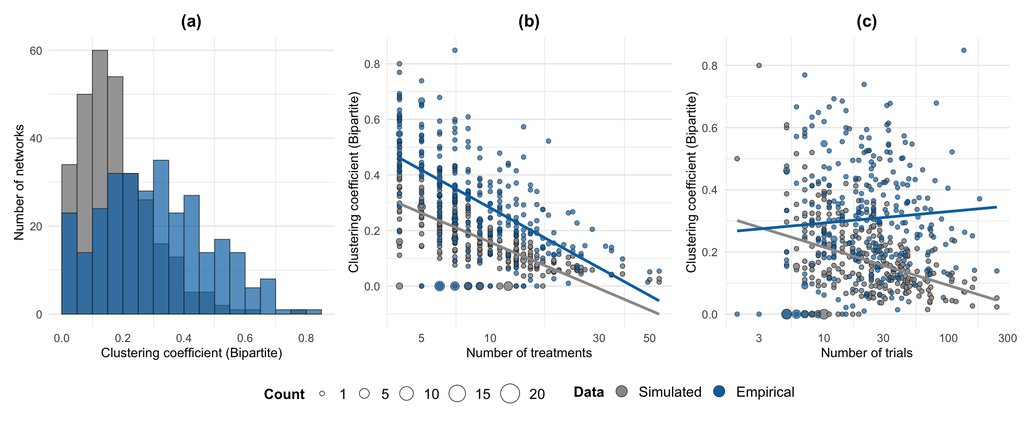

| Data | Networks | Minimum | Mean | Maximum |
| --- | --- | --- | --- | --- |
| Null Model | 300 | 0 | 0.176 | 0.800 |
| Database | 300 | 0 | 0.305 | 0.849 |

### Plot A: All networks

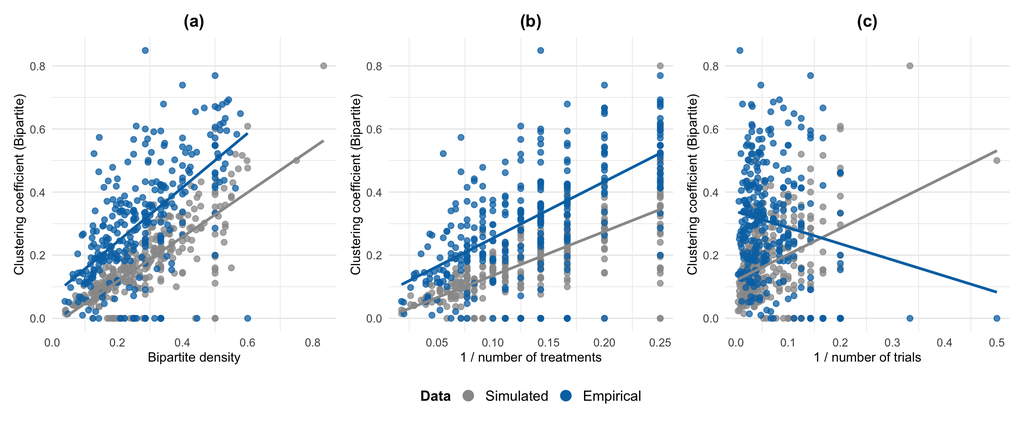

Bipartite clustering regressions for all networks

| Relationship | Data | Intercept | Slope | R-squared |
| --- | --- | --- | --- | --- |
| (a) Bipartite density | Simulated | -0.0239 | 0.7045 | 0.6164 |
| (a) Bipartite density | Empirical | 0.0704 | 0.8602 | 0.3886 |
| (b) 1 / N | Simulated | -0.0041 | 1.3970 | 0.5027 |
| (b) 1 / N | Empirical | 0.0742 | 1.7962 | 0.3836 |
| (c) 1 / M | Simulated | 0.1205 | 0.8213 | 0.1532 |
| (c) 1 / M | Empirical | 0.3384 | -0.5112 | 0.0258 |

### Plot B: Looped networks

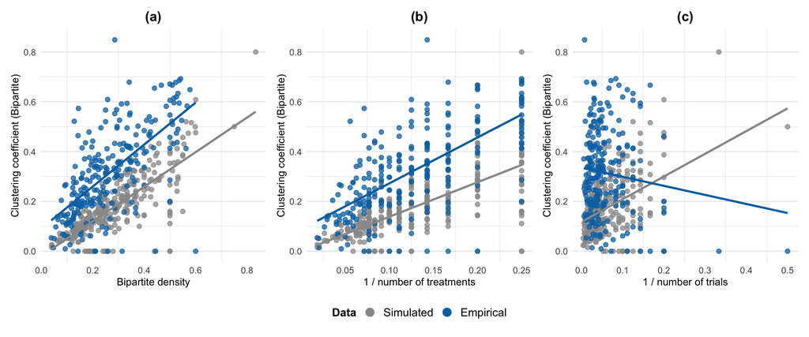

Bipartite clustering regressions for looped networks only

| Relationship | Data | Intercept | Slope | R-squared |
| --- | --- | --- | --- | --- |
| (a) Bipartite density | Simulated | -0.0192 | 0.6953 | 0.6398 |
| (a) Bipartite density | Empirical | 0.0909 | 0.8433 | 0.4234 |
| (b) 1 / N | Simulated | -0.0002 | 1.3864 | 0.5224 |
| (b) 1 / N | Empirical | 0.0884 | 1.8416 | 0.4377 |
| (c) 1 / M | Simulated | 0.1177 | 0.9116 | 0.1870 |
| (c) 1 / M | Empirical | 0.3352 | -0.3636 | 0.0126 |

# Degree assortativity

## Unipartite

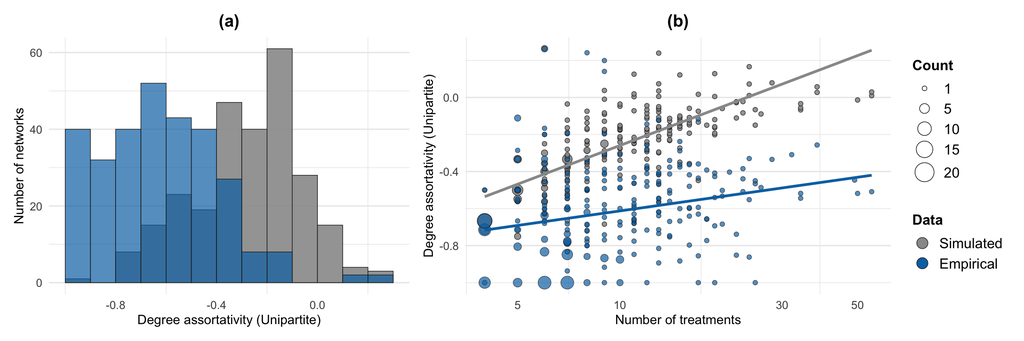

| Data | Networks | Minimum | Mean | Maximum |
| --- | --- | --- | --- | --- |
| Null Model | 264 | -1 | -0.274 | 0.263 |
| Database | 294 | -1 | -0.625 | 0.263 |

```
##     network_id N_treatments N_total_trials number_of_arms
## 393    570-108            8             25             51
## 444    570-160            6              8             17
## 564    570-285            9             72            149
## 591    570-313            9             22             44
##     number_of_distinct_treatment_comparisons mean_bipartite_trial_degree
## 393                                       11                    2.040000
## 444                                        7                    2.125000
## 564                                       15                    2.069444
## 591                                       13                    2.000000
##     mean_bipartite_treatment_degree mean_unipartite_weighted_degree
## 393                        6.375000                        6.750000
## 444                        2.833333                        3.333333
## 564                       16.555556                       18.444444
## 591                        4.888889                        4.888889
##     mean_unipartite_unweighted_degree   density bi_density avg_path_length
## 393                          2.750000 0.3928571  0.2550000        2.000000
## 444                          2.333333 0.4666667  0.3541667        1.866667
## 564                          3.333333 0.4166667  0.2299383        1.944444
## 591                          2.888889 0.3611111  0.2222222        1.944444
##     diameter   bi_apl unipartite_c bipartite_c assortativity bi_assortativity
## 393        4 3.075758    0.3913043   0.3306452     0.2413793       -0.1504398
## 444        4 2.989011    0.5454545   0.2962963     0.2631579       -0.2534170
## 564        4 2.630864    0.6279070   0.3365274     0.1992883       -0.2364283
## 591        4 3.531183    0.3103448   0.3275862     0.1404959               NA
##     deg_irreg bi_trial_deg_irreg bi_treatment_deg_irreg   type     Data
## 393 0.5747599         0.00922722              0.6270665 looped Database
## 444 0.2900000         0.02422145              0.3494810 looped Database
## 564 0.8962839         0.02157560              1.0403135 looped Database
## 591 0.2830579         0.00000000              0.2830579 looped Database
```

## Bipartite

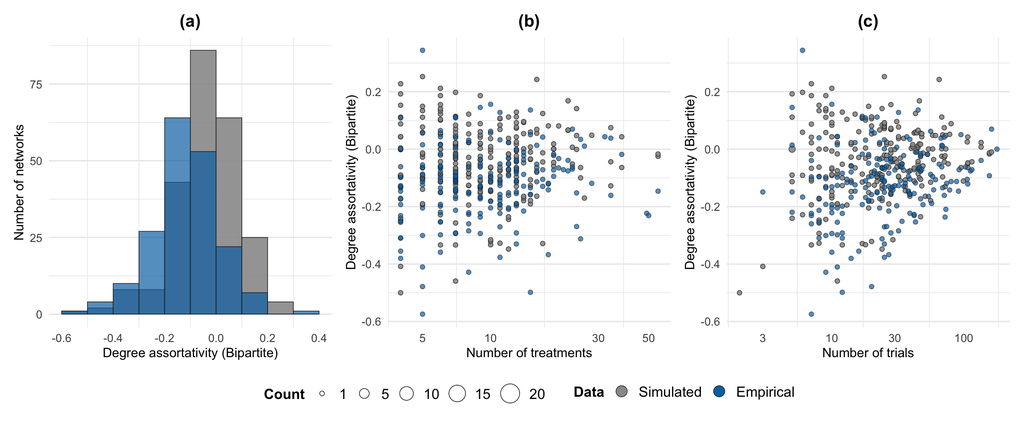

| Data | Networks | Minimum | Mean | Maximum |
| --- | --- | --- | --- | --- |
| Null Model | 241 | -0.500 | -0.038 | 0.253 |
| Database | 189 | -0.574 | -0.121 | 0.344 |

[output not shown]

## unipartite-vs-bipartite

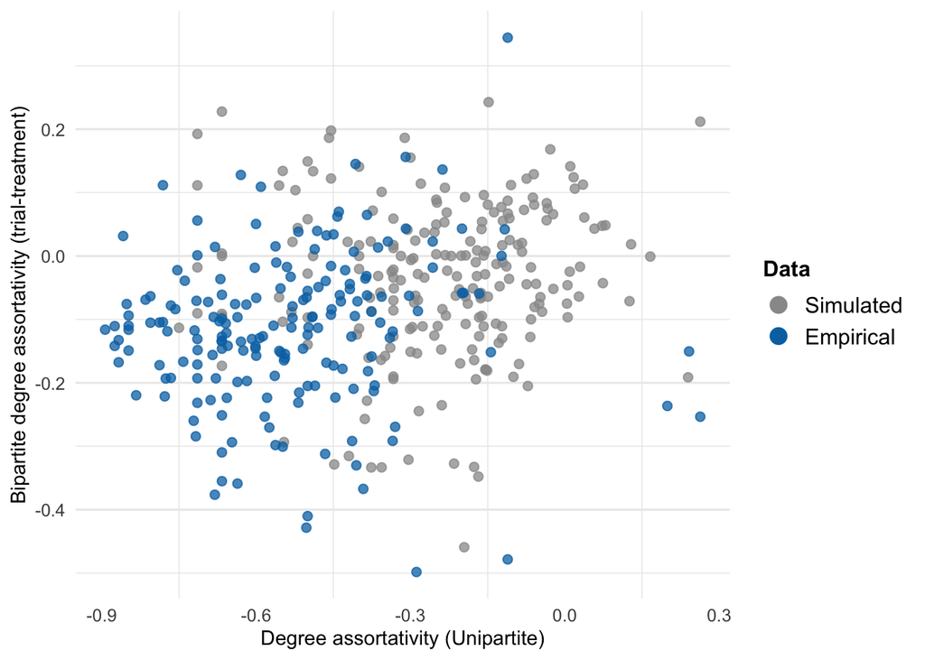

# Degree irregularity

## Unipartite

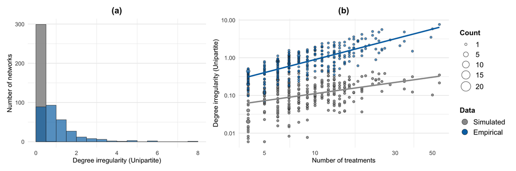

| Data | Networks | Minimum | Mean | Maximum |
| --- | --- | --- | --- | --- |
| Null Model | 300 | 0.006 | 0.141 | 0.540 |
| Database | 300 | 0.071 | 1.082 | 7.642 |

```
## Proportion of empirical networks having irr<1: 0.6066667
```

```
##         network_id N_treatments N_total_trials number_of_arms
## 202 copula_MNS_202            7              6             14
##     number_of_distinct_treatment_comparisons mean_bipartite_trial_degree
## 202                                        8                    2.333333
##     mean_bipartite_treatment_degree mean_unipartite_weighted_degree
## 202                               2                        2.857143
##     mean_unipartite_unweighted_degree   density bi_density avg_path_length
## 202                          2.285714 0.3809524  0.3333333        1.809524
##     diameter   bi_apl unipartite_c bipartite_c assortativity bi_assortativity
## 202        3 2.974359        0.375   0.3076923    -0.4545455        0.1977887
##     deg_irreg bi_trial_deg_irreg bi_treatment_deg_irreg   type
## 202      0.54         0.04081633              0.4285714 looped
```

```
## Doubling the number of treatments is associated with approximately a 2.2-fold change in unipartite irregularity.
```

## Bipartite trials

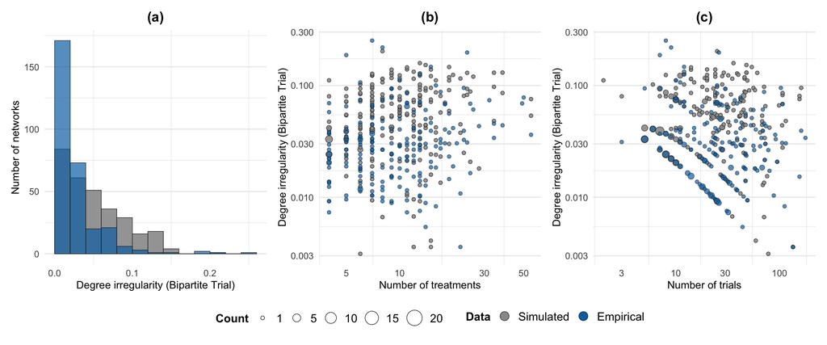

| Data | Networks | Minimum | Mean | Maximum |
| --- | --- | --- | --- | --- |
| Null Model | 300 | 0 | 0.049 | 0.203 |
| Database | 300 | 0 | 0.024 | 0.252 |

```
## Number of empirical networks having metric = 0: 1
```

```
## Number of empirical networks having metric <0.02: 171
```

```
## Number of empirical networks having metric >0.04: 56
```

```
## Number of simulated networks having metric >0.04: 156
```

## Bipartite treatments

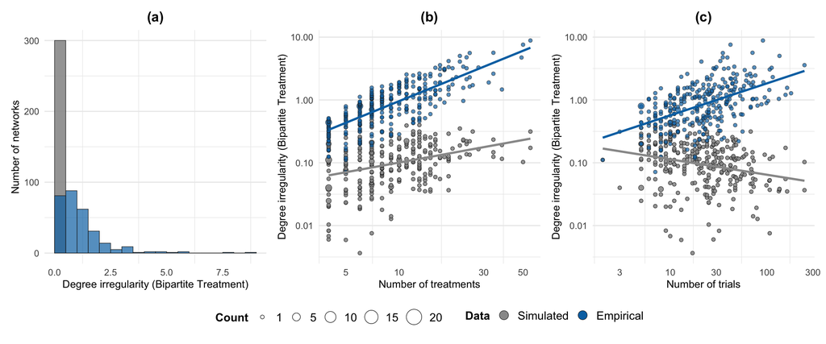

| Data | Networks | Minimum | Mean | Maximum |
| --- | --- | --- | --- | --- |
| Null Model | 300 | 0.004 | 0.127 | 0.475 |
| Database | 300 | 0.071 | 1.154 | 8.834 |

## Unipartite versus bipartite

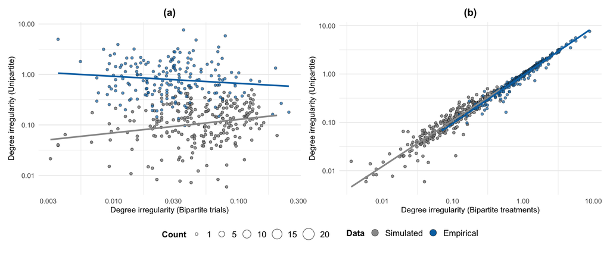

Log-log fitted-line parameters for unipartite degree irregularity versus bipartite trial- and treatment-degree irregularity

| Bipartite nodes | Data | Slope | Intercept | R-squared |
| --- | --- | --- | --- | --- |
| Trials | Simulated | 0.265 | -0.626 | 0.051 |
| Trials | Empirical | -0.140 | -0.316 | 0.016 |
| Treatments | Simulated | 0.954 | -0.009 | 0.871 |
| Treatments | Empirical | 0.996 | -0.030 | 0.966 |

# Mean degree relationships

## Mean degree and degree irregularity

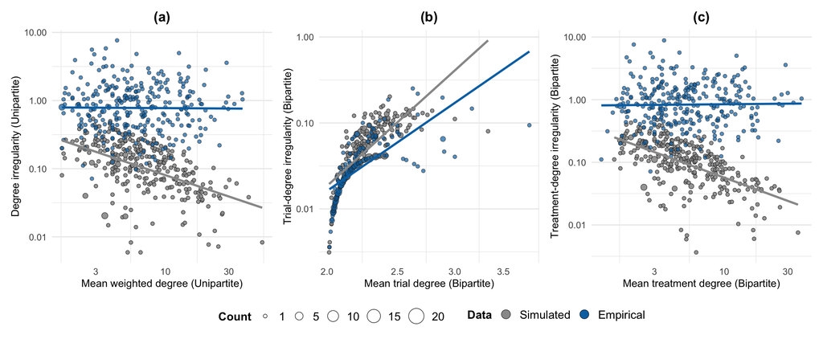

## Treatment-to-trial ratio and bipartite degree irregularity

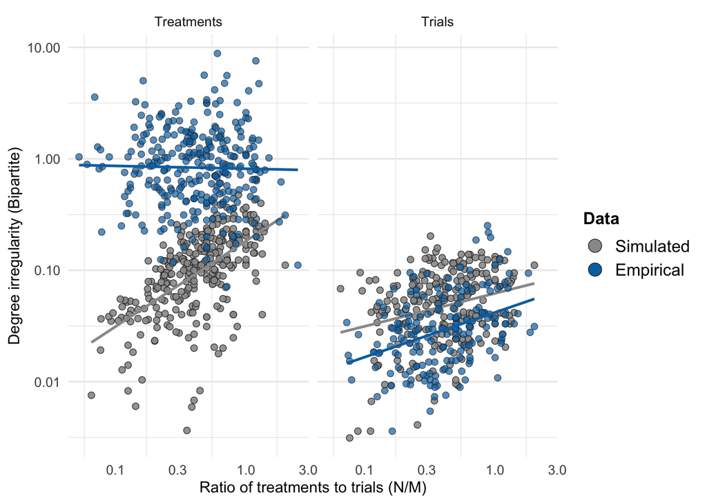

Log-log fitted-line parameters for bipartite trial- and treatment-degree irregularity versus the treatment-to-trial ratio

| Node type | Data | Slope | Intercept | R-squared |
| --- | --- | --- | --- | --- |
| Treatments | Simulated | 0.769 | -0.737 | 0.354 |
| Treatments | Empirical | -0.025 | -0.088 | 0.001 |
| Trials | Simulated | 0.296 | -1.207 | 0.070 |
| Trials | Empirical | 0.402 | -1.378 | 0.146 |

## Mean degree and degree assortativity

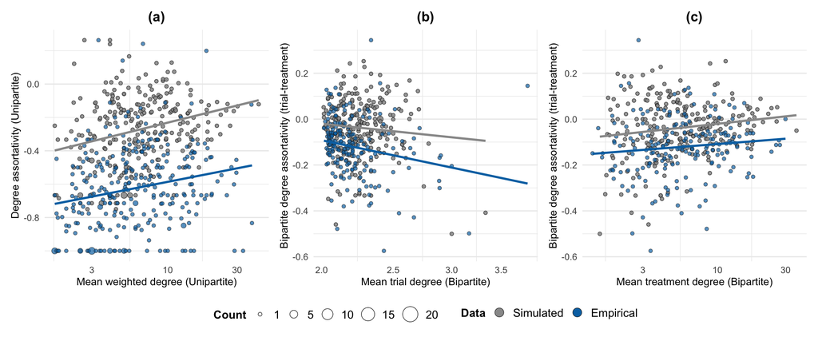

| Data | Edges | Proportion with multiplicity below 5 | Minimum multiplicity | Maximum multiplicity |
| --- | --- | --- | --- | --- |
| Null Model | 8445 | 0.974 | 1 | 13 |
| Database | 4366 | 0.871 | 1 | 92 |

| Data | Proportion of treatments with no more than two comparators |
| --- | --- |
| Null Model | 0.156 |
| Database | 0.626 |

# Saved comparison data

## Fitted-line parameter table

The original parameter rows are loaded from the results prepared by `null_model_sample.Rmd`. The mean-degree rows are fitted here with the same transformations used by the two mean-degree figures above.

Fitted-line parameters by metric, network representation, and axis.

| Metric | Network | X-axis | Y-axis | Database Slope | Database Intercept | Database R<sup>2</sup> | Null Model Slope | Null Model Intercept | Null Model R<sup>2</sup> |
| --- | --- | --- | --- | --- | --- | --- | --- | --- | --- |
| **Average path length** | Unipartite | log10(N) | Average path length (Unipartite) | 1.089 | 0.733 | 0.523 | 1.157 | 0.421 | 0.319 |
|  | Bipartite | log10(N) | Average path length (Bipartite) | 1.573 | 1.239 | 0.424 | 2.609 | 0.610 | 0.613 |
|  |  | log10(M) | Average path length (Bipartite) | 0.086 | 2.615 | 0.003 | 0.583 | 2.311 | 0.078 |
| **Clustering coefficient** | Unipartite | log10(N) | Clustering coefficient (Unipartite) | -0.367 | 0.656 | 0.105 | -0.506 | 1.099 | 0.226 |
|  | Bipartite | log10(N) | Clustering coefficient (Bipartite) | -0.452 | 0.733 | 0.352 | -0.349 | 0.507 | 0.448 |
|  |  | log10(M) | Clustering coefficient (Bipartite) | 0.037 | 0.257 | 0.005 | -0.123 | 0.338 | 0.140 |
| **Degree assortativity** | Unipartite | log10(N) | Degree assortativity (Unipartite) | 0.260 | -0.873 | 0.062 | 0.695 | -0.954 | 0.563 |
|  |  | Mean weighted degree | Degree assortativity (Unipartite) | 0.170 | -0.756 | 0.045 | 0.215 | -0.446 | 0.075 |
|  | Bipartite | log10(N) | Bipartite degree assortativity (trial-treatment) | 0.074 | -0.194 | 0.021 | 0.023 | -0.061 | 0.002 |
|  |  | log10(M) | Bipartite degree assortativity (trial-treatment) | 0.081 | -0.234 | 0.049 | 0.054 | -0.111 | 0.024 |
|  |  | Mean trial degree | Bipartite degree assortativity (trial-treatment) | -0.678 | 0.112 | 0.046 | -0.335 | 0.081 | 0.008 |
|  |  | Mean treatment degree | Bipartite degree assortativity (trial-treatment) | 0.049 | -0.157 | 0.013 | 0.068 | -0.088 | 0.024 |
| **Degree irregularity** | Unipartite | log10(N) | log10(Degree irregularity (Unipartite)) | 1.154 | -1.202 | 0.579 | 0.624 | -1.576 | 0.151 |
|  |  | Mean weighted degree | log10(Degree irregularity (Unipartite)) | -0.012 | -0.099 | 0.000 | -0.656 | -0.439 | 0.248 |
| **Density** | Unipartite | log10(N) | log10(Network density (Unipartite)) | -0.922 | 0.382 | 0.744 | -0.658 | 0.363 | 0.486 |
|  | Bipartite | log10(N) | log10(Network density (Bipartite)) | -0.967 | 0.297 | 0.973 | -0.968 | 0.314 | 0.977 |
|  |  | log10(M) | log10(Network density (Bipartite)) | -0.350 | -0.155 | 0.298 | -0.411 | -0.061 | 0.446 |
| **Diameter** | Unipartite | log10(N) | Diameter (Unipartite) | 2.252 | 0.633 | 0.287 | 3.213 | -0.349 | 0.327 |
| **Treatment-degree irregularity** | Bipartite | log10(N) | log10(Treatment-degree irregularity (Bipartite)) | 1.147 | -1.165 | 0.586 | 0.514 | -1.510 | 0.107 |
|  |  | log10(M) | log10(Treatment-degree irregularity (Bipartite)) | 0.509 | -0.754 | 0.270 | -0.245 | -0.700 | 0.062 |
|  |  | Treatment-to-trial ratio (N/M) | log10(Treatment-degree irregularity (Bipartite)) | -0.025 | -0.088 | 0.001 | 0.769 | -0.737 | 0.354 |
|  |  | Mean treatment degree | log10(Treatment-degree irregularity (Bipartite)) | 0.019 | -0.093 | 0.000 | -0.780 | -0.465 | 0.348 |
| **Trial-degree irregularity** | Bipartite | log10(N) | log10(Trial-degree irregularity (Bipartite)) | 0.238 | -1.776 | 0.033 | 0.279 | -1.593 | 0.039 |
|  |  | log10(M) | log10(Trial-degree irregularity (Bipartite)) | -0.199 | -1.264 | 0.045 | -0.080 | -1.211 | 0.008 |
|  |  | Treatment-to-trial ratio (N/M) | log10(Trial-degree irregularity (Bipartite)) | 0.402 | -1.378 | 0.146 | 0.296 | -1.207 | 0.070 |
|  |  | Mean trial degree | log10(Trial-degree irregularity (Bipartite)) | 5.816 | -3.541 | 0.514 | 7.627 | -4.028 | 0.566 |